# Isomap - Isometric Mapping (ou Mapeamento Isométrico)

## O que é ?

- Método não linear de redução de dimensionalidade
- Extensão do MSD (Multidimensional Scaling ou Escalonamento Multidimensional)
- Estrutura de grafo com distâncias geodésicas (arestas ponderadas)

## Conjunto de dados Curva S

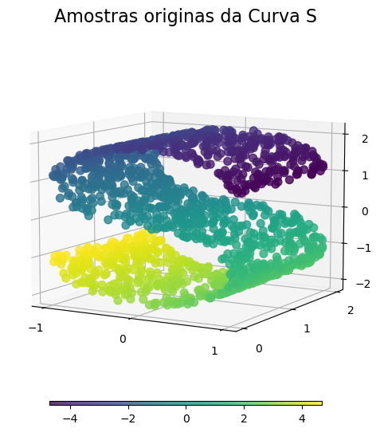

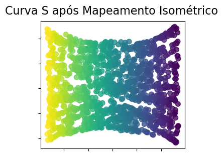

## Aplicações

O algoritmo Isomap é utilizado principalmente para lidar com problemas onde é crucial lidar com dados de alta dimensionalidade. Algumas das principais aplicações são:

- Análise de Imagens e Visão Computacional
- Processamento de Sinais
- Reconhecimento de Padrões e Aprendizado de Máquina
- Bioinformática
- Robótica e Processamento de Movimento
- Visualização de Dados e Análise Exploratória

## Vantagens

### Preservação de Estruturas Não Lineares

O Isomap é capaz de capturar e preservar estruturas não lineares nos dados, o que é essencial para conjuntos de dados complexos.

### Redução de Dimensionalidade com Preservação de Relações de Distância

Ele preserva as relações de distância entre os pontos, o que é valioso ao reduzir a dimensionalidade sem perder informações importantes.

### Robustez a Ruídos

Significa que pode lidar com certos graus de imprecisão nos dados de entrada.

### Boa Representação Visual

Ajuda na visualização de dados de alta dimensão em espaços menores, o que é útil para compreender a estrutura subjacente dos dados.

## Desvantagens

### Sensibilidade à Escolha de Parâmetros

O desempenho do Isomap pode depender da escolha adequada de parâmetros, como o número de vizinhos a considerar, e isso pode impactar significativamente os resultados.

### Custo Computacional Elevado

Para conjuntos de dados grandes, o Isomap pode ser computacionalmente intensivo, pois envolve o cálculo de distâncias geodésicas em um espaço de alta dimensão.

### Dependência de Estrutura Geométrica

O algoritmo assume que os dados residem em uma estrutura subjacente que pode ser representada como uma variedade ou superfície, o que pode não ser verdadeiro para todos os conjuntos de dados.

### Possibilidade de 'Efeito Elástico'

Em espaços de alta dimensão, há uma chance de que a representação reduzida dos dados perca algumas informações, levando ao que é conhecido como "efeito elástico" ou distorção da estrutura original.

## Exemplo de Código

#### Aprendizagem múltipla em dígitos manuscritos (parcial)

Autores:

- Fabian Pedregosa fabian.pedregosa@inria.fr
- Olivier Grisel olivier.grisel@ensta.org
- Mathieu Blondel mathieu@mblondel.org
- Gael Varoquaux
- Guillaume Lemaitre g.lemaitre58@gmail.com

Licença: BSD 3 clause (C) INRIA 2011

Disponível em: [Scikit Learn](https://scikit-learn.org/stable/auto_examples/manifold/plot_lle_digits.html#sphx-glr-auto-examples-manifold-plot-lle-digits-py)

```python
# Realiza as importações necessárias
import matplotlib.pyplot as plt
import numpy as np

from sklearn.manifold import Isomap
from sklearn.pipeline import make_pipeline
from sklearn.datasets import load_digits
from matplotlib import offsetbox
from sklearn.preprocessing import MinMaxScaler
from time import time
```

```python
# Gera o conjunto de dados
digits = load_digits(n_class=6)
X, y = digits.data, digits.target
n_samples, n_features = X.shape
n_neighbors = 30
```

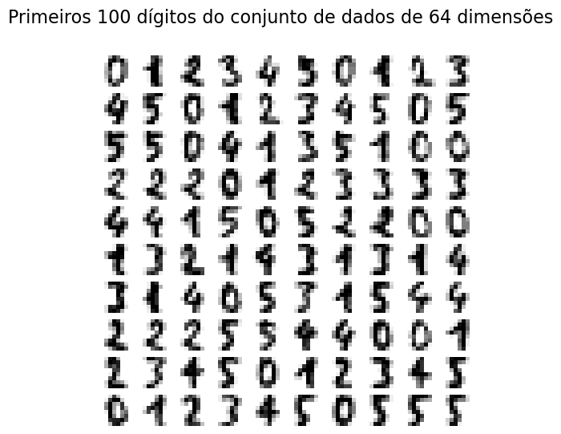

```python
# Mostra os primeiros 100 dígitos do conjunto de dados
fig, axs = plt.subplots(nrows=10, ncols=10, figsize=(6, 6))
for idx, ax in enumerate(axs.ravel()):
    ax.imshow(X[idx].reshape((8, 8)), cmap=plt.cm.binary)
    ax.axis("off")
_ = fig.suptitle("Primeiros 100 dígitos do conjunto de dados de 64 dimensões", fontsize=16)
```

```python
# Define função para plotar os dados após aplicação do algoritmo
def plot_embedding(X, title):
    _, ax = plt.subplots()
    X = MinMaxScaler().fit_transform(X)

    for digit in digits.target_names:
        ax.scatter(
            *X[y == digit].T,
            marker=f"${digit}$",
            s=60,
            color=plt.cm.Dark2(digit),
            alpha=0.425,
            zorder=2,
        )
    shown_images = np.array([[1.0, 1.0]])  # just something big
    for i in range(X.shape[0]):
        # plot every digit on the embedding
        # show an annotation box for a group of digits
        dist = np.sum((X[i] - shown_images) ** 2, 1)
        if np.min(dist) < 4e-3:
            # don't show points that are too close
            continue
        shown_images = np.concatenate([shown_images, [X[i]]], axis=0)
        imagebox = offsetbox.AnnotationBbox(
            offsetbox.OffsetImage(digits.images[i], cmap=plt.cm.gray_r), X[i]
        )
        imagebox.set(zorder=1)
        ax.add_artist(imagebox)

    ax.set_title(title)
    ax.axis("off")
```

```python
# Declara os algoritmos que irão operar sobre o conjunto de dados
# Nesse caso, apenas o Isomap
embeddings = {
    "Isomap embedding": Isomap(n_neighbors=n_neighbors, n_components=2),

}
```

```python
# Calcula a projeção dos dados após a aplicação do algoritmo e o tempo de execução
# Nesse caso, apenas o Isomap
projections, timing = {}, {}
for name, transformer in embeddings.items():
    if name.startswith("Linear Discriminant Analysis"):
        data = X.copy()
        data.flat[:: X.shape[1] + 1] += 0.01  # Make X invertible
    else:
        data = X

    print(f"Computing {name}...")
    start_time = time()
    projections[name] = transformer.fit_transform(data, y)
    timing[name] = time() - start_time
```

```
Computing Isomap embedding...
```

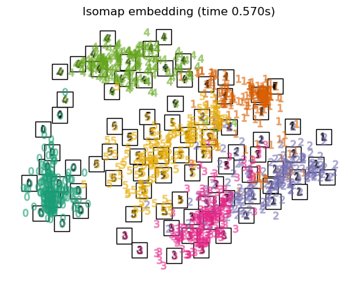

```python
# Mostra os resultados
for name in timing:
    title = f"{name} (time {timing[name]:.3f}s)"
    plot_embedding(projections[name], title)

plt.show()
```